[figure not shown]

# Minería de datos

## Práctica Scikit-Learn (Visualización)

## Docentes

- José Francisco Diez Pastor

## Estudiantes (1-2)

- Victor de Marco
- Alejandro Diez

## Descripción de los datos

Vamos a trabajar con el conjunto de datos de ejemplo `breast_cancer`

Se trata de un conjunto de datos de 569 instancias. Tiene 30 atributos relativos a características de la región candidata a tumor (radio, textura, perímetro, área, suavidad, ...) y la clase.

La clase puede ser:

- WDBC-Malignant
- WDBC-Benign

## Tareas

1. Selecciona mejor árbol para visualización. **(5 Puntos)**
2. Visualiza predicciones dudosas.**(5 Puntos)**

### Tarea 1. Selecciona mejor árbol para visualización (5 Puntos)

Se va a entrenar con el dataset `breast_cancer` un modelo de tipo GridSearchCV que en su interior va a tener un árbol de clasificación. GridSearchCV va a evaluar cada opción usando una validación cruzada interna de 5 folds.

- El diccionario de parámetros de búsqueda que se van a utilizar es el siguiente:

```
param_grid = {
    "max_depth": [None, 2, 3, 4, 5, 6, 7, 8, 9, 10, 15, 20],
    "min_samples_split": [2, 4, 8, 16, 32, 64, 128, 256],
    "min_samples_leaf": [1, 2, 3, 5, 8, 12, 16, 20, 30]
}
```

Se va a invocar al método `fit` del método GridSearchCV y después se van a recorrer los resultados que están almacenados en el campo `cv_results_`. Para cada configuración evaluada va a almacenar la tasa de acierto cada prueba.

Crea un DataFrame con los resultados, el DataFrame deberá de tener como columnas:

- max_depth
- min_samples_split
- min_samples_leaf
- accuracy_score

Crea una función `generate_rules` que a partir de un árbol de decisión entrenado obtenga un conjunto de reglas. **Pista**: Investiga el método `export_text`.

Crea una función `get_num_rules` que obtenga el número de reglas. **Pista** Los árboles tienen un atributo `arbol.tree_.n_leaves` que te devuelve el número de hojas (ejemplo suponiendo que la variable se llama `arbol`).

Aplica la función `get_num_rules` al DataFrame de resultados para crear una nueva columna `num_rules`

Dibuja un `scatter plot` representando `accuracy_score` y `num_rules`

```python
import numpy as np
import pandas as pd
import matplotlib.pyplot as plt

from sklearn.datasets import load_breast_cancer
from sklearn.tree import DecisionTreeClassifier, export_text
from sklearn.model_selection import GridSearchCV

# Carga el dataset breast_cancer
data = load_breast_cancer()
X = data.data
y = data.target
feature_names = data.feature_names
```

```python
def generate_rules(tree, feature_names):
    """
    A partir de un árbol de decisión entrenado, retorna un string con el conjunto de reglas.
    """
    return export_text(tree, feature_names=feature_names)

def get_num_rules(tree):
    """
    Retorna el número de reglas (equivalente al número de hojas) en el árbol.
    """
    return tree.get_n_leaves()
```

```
tree = DecisionTreeClassifier(min_samples_split=512)
tree.fit(X,y)

print(generate_rules(tree, feature_names))
print(get_num_rules(tree))

tree = DecisionTreeClassifier(min_samples_split=256)
tree.fit(X,y)

print(generate_rules(tree, feature_names))
print(get_num_rules(tree))
```

```
|--- worst radius <= 16.80
|   |--- class: 1
|--- worst radius >  16.80
|   |--- class: 0

2
|--- worst radius <= 16.80
|   |--- worst concave points <= 0.14
|   |   |--- radius error <= 1.05
|   |   |   |--- area error <= 38.60
|   |   |   |   |--- smoothness error <= 0.00
|   |   |   |   |   |--- class: 1
|   |   |   |   |--- smoothness error >  0.00
|   |   |   |   |   |--- worst texture <= 33.27
|   |   |   |   |   |   |--- class: 1
|   |   |   |   |   |--- worst texture >  33.27
|   |   |   |   |   |   |--- class: 1
|   |   |   |--- area error >  38.60
|   |   |   |   |--- class: 1
|   |   |--- radius error >  1.05
|   |   |   |--- class: 0
|   |--- worst concave points >  0.14
|   |   |--- class: 0
|--- worst radius >  16.80
|   |--- class: 0

7
```

```python
tree = DecisionTreeClassifier(min_samples_split=512)
tree.fit(X,y)

print(generate_rules(tree, feature_names))
print(get_num_rules(tree))

tree = DecisionTreeClassifier(min_samples_split=256)
tree.fit(X,y)

print(generate_rules(tree, feature_names))
print(get_num_rules(tree))
```

```
|--- worst radius <= 16.80
|   |--- class: 1
|--- worst radius >  16.80
|   |--- class: 0

2
|--- worst radius <= 16.80
|   |--- worst concave points <= 0.14
|   |   |--- area error <= 91.56
|   |   |   |--- area error <= 38.60
|   |   |   |   |--- smoothness error <= 0.00
|   |   |   |   |   |--- class: 1
|   |   |   |   |--- smoothness error >  0.00
|   |   |   |   |   |--- worst texture <= 33.27
|   |   |   |   |   |   |--- class: 1
|   |   |   |   |   |--- worst texture >  33.27
|   |   |   |   |   |   |--- class: 1
|   |   |   |--- area error >  38.60
|   |   |   |   |--- class: 1
|   |   |--- area error >  91.56
|   |   |   |--- class: 0
|   |--- worst concave points >  0.14
|   |   |--- class: 0
|--- worst radius >  16.80
|   |--- class: 0

7
```

```python
# 1. Definir el diccionario de parámetros
param_grid = {
    "max_depth": [None, 2, 3, 4, 5, 6, 7, 8, 9, 10, 15, 20],
    "min_samples_split": [2, 4, 8, 16, 32, 64, 128, 256],
    "min_samples_leaf": [1, 2, 3, 5, 8, 12, 16, 20, 30],
}

# 2. Crear y ajustar GridSearchCV con validación cruzada interna de 5 folds
grid_search = GridSearchCV(DecisionTreeClassifier(), param_grid, cv=5)
grid_search.fit(X, y)

# 4. Extraer resultados de cv_results_ y crear un DataFrame
results_df = pd.DataFrame(grid_search.cv_results_["params"])
results_df["accuracy_score"] = grid_search.cv_results_["mean_test_score"]

# 5. Para cada combinación evaluada, entrenamos un árbol en todo el dataset y obtenemos el número de reglas.
num_rules = []
for _, data in results_df.iterrows():
    model = DecisionTreeClassifier(
        max_depth=None if pd.isna(data["max_depth"]) else int(data["max_depth"]),
        min_samples_split=int(data["min_samples_split"]),
        min_samples_leaf=int(data["min_samples_leaf"]),
    )
    model.fit(X, y)
    num_rules.append(get_num_rules(model))

results_df["num_rules"] = num_rules

# Mostrar una muestra del DataFrame con los resultados
print("Resultados:")
display(
    results_df.head(10).assign(max_depth=lambda e: e["max_depth"].fillna(""))[
        [
            "max_depth",
            "min_samples_split",
            "min_samples_leaf",
            "accuracy_score",
            "num_rules",
        ]
    ]
)
```

```
Resultados:
```

|  | max_depth | min_samples_split | min_samples_leaf | accuracy_score | num_rules |
| --- | --- | --- | --- | --- | --- |
| 0 |  | 2 | 1 | 0.915634 | 22 |
| 1 |  | 4 | 1 | 0.927899 | 22 |
| 2 |  | 8 | 1 | 0.917358 | 18 |
| 3 |  | 16 | 1 | 0.915603 | 15 |
| 4 |  | 32 | 1 | 0.922667 | 11 |
| 5 |  | 64 | 1 | 0.915650 | 10 |
| 6 |  | 128 | 1 | 0.915650 | 10 |
| 7 |  | 256 | 1 | 0.922621 | 7 |
| 8 |  | 2 | 2 | 0.912032 | 20 |
| 9 |  | 4 | 2 | 0.920866 | 20 |

[output not shown]

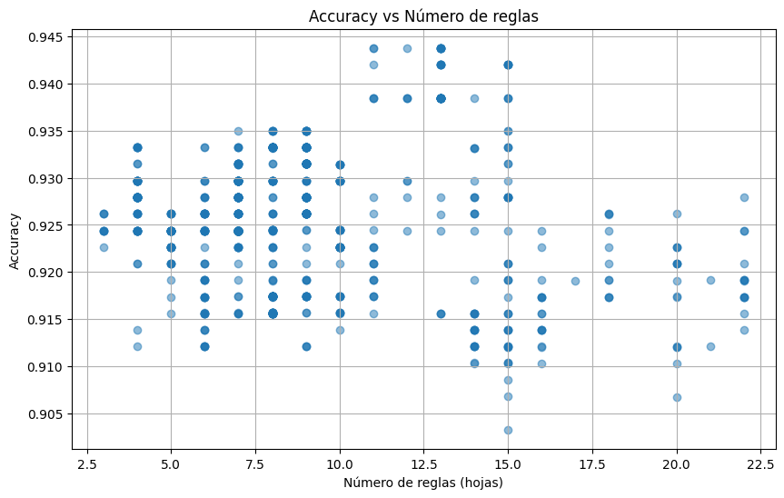

```python
# 7. Dibujar un scatter plot representando accuracy_score vs num_rules
plt.figure(figsize=(10, 6))
plt.scatter(results_df['num_rules'], results_df['accuracy_score'], alpha=0.5)
plt.xlabel('Número de reglas (hojas)')
plt.ylabel('Accuracy')
plt.title('Accuracy vs Número de reglas')
plt.grid(True)
plt.show()
```

[figure not shown]

```python
# Ejemplo de uso de generate_rules:
# Entrenamos un árbol con los mejores parámetros según la figura.
# Vemos que hay un árbol con 4 hojas que alcanza una accuracy muy alta.
# Usamos pandas para seleccionar los parámetros del mejor árbol de 4 hojas y lo visualizamos

simple_trees = results_df[results_df["num_rules"] <= 4]

# Seleccionamos el que tenga mejor accuracy entre ellos
best_simple_tree = simple_trees.loc[simple_trees["accuracy_score"].idxmax()]
# Reordenar columnas y convertir todo a string para que el dtype sea object
ordered = best_simple_tree[["max_depth", "min_samples_split", "min_samples_leaf", "accuracy_score", "num_rules"]].copy()

# Convertir cada valor al tipo adecuado y luego a string
ordered["max_depth"] = int(ordered["max_depth"])
ordered["min_samples_split"] = int(ordered["min_samples_split"])
ordered["min_samples_leaf"] = int(ordered["min_samples_leaf"])
ordered["accuracy_score"] = float(ordered['accuracy_score'])
ordered["num_rules"] = int(ordered["num_rules"])

# Mostrar resultado
print("Arbol elegido")
print(ordered.astype("object"))

# Entrenar el mejor árbol simple con esos parámetros
best_model = DecisionTreeClassifier(
    max_depth=None if pd.isna(best_simple_tree["max_depth"]) else int(best_simple_tree["max_depth"]),
    min_samples_split=int(best_simple_tree["min_samples_split"]),
    min_samples_leaf=int(best_simple_tree["min_samples_leaf"]),
)
best_model.fit(X, y)

# Mostrar reglas
print("\nReglas del mejor árbol simple:")
print(generate_rules(best_model, feature_names))
```

```
Arbol elegido
max_depth                 2.0
min_samples_split         2.0
min_samples_leaf          8.0
accuracy_score       0.933225
num_rules                 4.0
Name: 104, dtype: object

Reglas del mejor árbol simple:
|--- worst radius <= 16.80
|   |--- worst concave points <= 0.14
|   |   |--- class: 1
|   |--- worst concave points >  0.14
|   |   |--- class: 0
|--- worst radius >  16.80
|   |--- mean texture <= 16.11
|   |   |--- class: 1
|   |--- mean texture >  16.11
|   |   |--- class: 0
```

[output not shown]

### Tarea 2. Visualiza predicciones dudosas.**(5 Puntos)**

Ahora se va a probar el dataset de `breast_cancer` con un:

- RandomForest con 100 árboles.

Evalua el Random Forest mediante validación cruzada (10 folds).

Utiliza ese Random Forest para predecir las instancias del conjunto de datos, utiliza `predict_proba` para obtener probabilidades.

Selecciona casos en los que las probabilidades entre las clases son más cercanas (el clasificador no sabe que elegir).

Selecciona 2 casos, los dos más dudosos y explica las predicciones para esos casos con LIME.

```python
#!pip install lime
```

```python
import numpy as np
import pandas as pd
import matplotlib.pyplot as plt

from sklearn.datasets import load_breast_cancer
from sklearn.model_selection import cross_val_score
from sklearn.ensemble import RandomForestClassifier

import lime
import lime.lime_tabular

# 1. Cargar el dataset de breast_cancer
data = load_breast_cancer()
X = data.data
y = data.target
feature_names = data.feature_names
class_names = data.target_names

# 2. Definir los clasificadores
# Clasificador 1: RandomForest con 100 árboles (random_state 42)
rf = RandomForestClassifier(n_estimators=100, random_state=42)



# Evaluar RandomForest con CV
accuracy_rf = cross_val_score(rf, X, y, cv=10).mean()
print("RandomForest accuracy:", accuracy_rf)




# 5. Predecir probabilidades en todo el conjunto
# Usamos predict_proba, el cual retorna un array de shape (n_samples, 2) para clasificación binaria
rf.fit(X, y)
probas = rf.predict_proba(X)

# 6. Seleccionar casos en los que las probabilidades son más cercanas
dudas = np.abs(probas[:, 0] - probas[:, 1])
most_doubtful = np.argsort(dudas)[:2]
idx0 = most_doubtful[0]
idx1 = most_doubtful[1]
print("Las más dudosas son las posiciones:")
print(idx0, idx1)
```

```
RandomForest accuracy: 0.9631578947368421
Las más dudosas son las posiciones:
135 40
```

[output not shown]

```python
# 7. Explicar las predicciones para uno de esos casos ambiguos con LIME
explainer = lime.lime_tabular.LimeTabularExplainer(
    X,
    feature_names=feature_names,
    class_names=class_names,
    discretize_continuous=True,
    mode="classification"
)
exp0 = explainer.explain_instance(X[idx0], rf.predict_proba, num_features=10)
exp0.show_in_notebook(show_table=True)
exp1 = explainer.explain_instance(X[idx1], rf.predict_proba, num_features=10)
exp1.show_in_notebook(show_table=True)
```

[figure not shown]